# Poverty, not the poor

Journal club · Brady (2023)

Jan Pfänder

14 October 2026

## Why this paper

A tension that keeps growing when psychology studies social phenomena: the **i-frame** and the **s-frame** (Chater and Loewenstein 2023)

Poverty illustrates it unusually well: a huge, stable, structural problem with a large behavioural-science literature on the individuals in it

A concrete case for thinking the tension through

The field asks why **the poor** are poor.

Brady asks why the United States has so much **poverty**. (Brady 2023)

## Overview

1. The United States has systemically high poverty
2. Three prevailing approaches, and why they fail
3. Political explanations
4. Perspectives for psychology

# 1. Systemically high poverty

## How poverty is measured here

- Relative measure: poor if household income is below 50% of the median
- Income after taxes, tax credits and transfers (“post-fisc”), equivalised by household size
- Data: Luxembourg Income Study (LIS), rich democracies, 1980 to 2020

## Five patterns of poverty in the U.S.

- a huge share of the population
- a perennial outlier among rich democracies
- staggeringly high for certain groups
- unexpectedly high for those who “play by the rules”
- pervasive across groups and places

## A huge share of the population

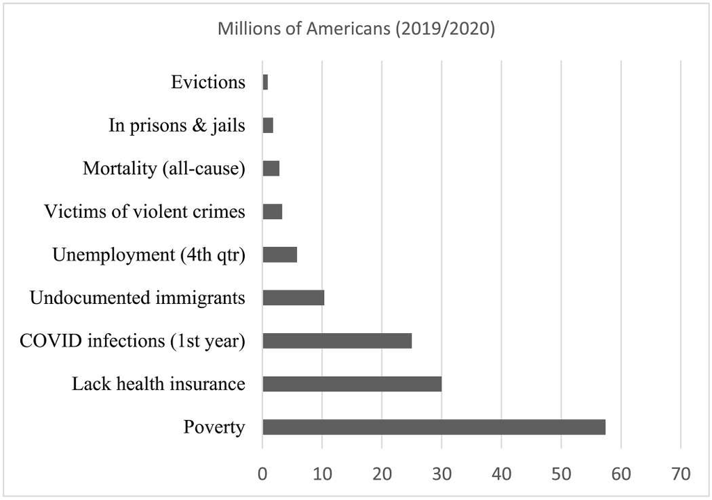

Millions of people in the United States experiencing major social problems (2019 or 2020). Far more people are in poverty than experience more visible problems. Brady (2023), Fig. 1.

## A perennial outlier

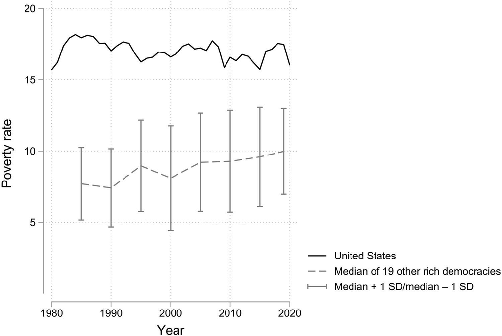

Poverty rate in the United States (solid line) and the median of 19 other rich democracies (dashed line, with ± one cross-national SD), 1980–2020. Brady (2023), Fig. 2.

## Staggeringly high for some groups

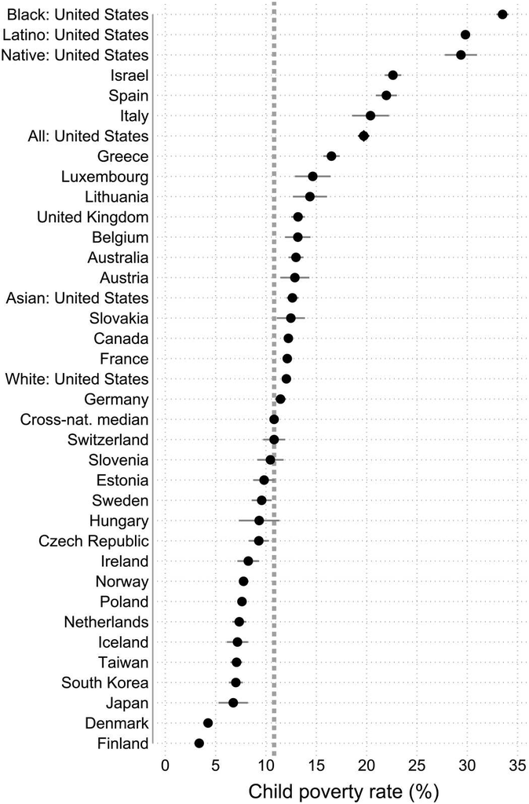

Child poverty rates for U.S. ethno-racial groups (2016–2020) and for 30 rich democracies, with 95% CIs. Dashed line: median child poverty rate across the 30 rich democracies. Brady (2023), Fig. 3.

## Unexpectedly high for those who “play by the rules”

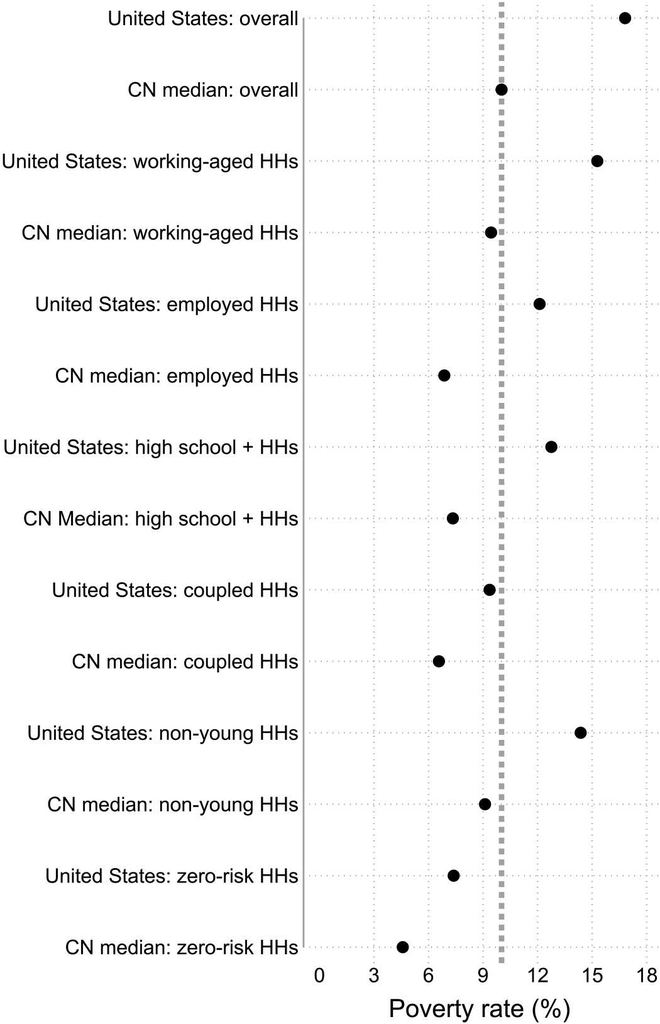

Poverty rates for the overall population and for non-risk groups among working-aged households (HHs), United States (2016–2020) versus the cross-national (CN) median of 31 rich democracies. Dotted line: CN median for the overall population. Brady (2023), Fig. 5.

## Pervasive across groups and places

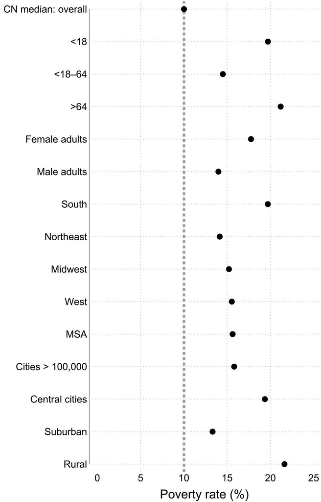

Poverty rates for age groups, adult women and men, regions and places in the United States (2016–2020). Dotted line: cross-national median poverty rate for the overall population. Brady (2023), Fig. 6.

# 2. Three prevailing approaches

## Three approaches to the individual poor

1. fixing the poor
2. dramatizing the poor
3. cultural explanations

## (i) Fixing the poor

“who is poor” explains “why there is poverty”

The poor are poor because they adopt the wrong behaviours:

- joblessness
- low education
- young headship
- single motherhood

Anti-poverty strategy: reduce the share of the population with these risks

## (i) Fixing the poor: prevalences and penalties

**Prevalence**: the share of the population with a risk

**Penalty**: how much more likely a risk makes you to be poor

The United States does not stand out for having high prevalences but does stand out for having the highest penalties among rich democracies.

## (ii) Dramatizing the poor

- Ethnography and intensive interviews: vivid, often shocking accounts of the daily lives of poor individuals (*Evicted*, *$2.00 a Day*, *On the Run*)
- The theory of change: humanising the poor evokes compassion, and compassion shifts the policy agenda

Brady’s critique:

- Drama focuses on individuals: their life history, unfortunate circumstances, or counterproductive behavior that caused such dire straits
- “Many have tremendous compassion for the poor but maintain an individualistic theory of the causes of and solutions for poverty.”
- Drama overrepresents stereotypical groups, focuses on symptoms (eviction), and downplays effective policy

## Who is actually poor?

*If one were to construct a composite “typical” poor person in the United States based on the most common populations in multiple categories, it would be a white, 35- to 45-year-old woman, with a high school education, in a coupled and employed household with no children, and living in a metropolitan area in the South.*

## Who is actually poor?

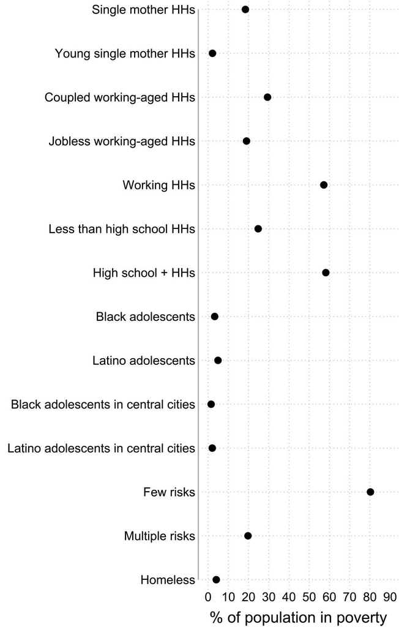

Share of the U.S. population in poverty (2016–2020) that belongs to stereotypical versus typical groups. Brady (2023), Fig. 7.

## (iii) Cultural explanations: the claim

- People in poverty share a distinct culture
- That culture produces behaviour that keeps them poor: not finishing school, not marrying, not working
- Poverty then reinforces the culture, and passes it on to the next generation

## (iii) Cultural explanations: why Brady rejects them

- **Circular.** If culture causes poverty and poverty causes culture, what made poverty high in the first place?
- **No comparison.** Studies of poor people in poor neighbourhoods, with no non-poor group and no test against rival explanations
- **Wrong answer.** Evidence points to, e.g., employer discrimination and segregated, lower-quality schools, not to the values of the poor

# 3. Political explanations

Poverty is a problem of resource **distribution**.

**Institutions** make **policy**. Policy makes **poverty**.

## Four themes

1. **Social policy generosity** is a requirement for low poverty
2. **Penalties** on risks are political choices
3. **Power resources**: who is organised enough to win generous policy
4. **Institutions**: laws and rules that lock in the past

## (a) Social policy generosity

> There has never been a country in the modern history of capitalist democracies that accomplished sustainably low poverty without a large welfare state.

## (a) Social policy generosity

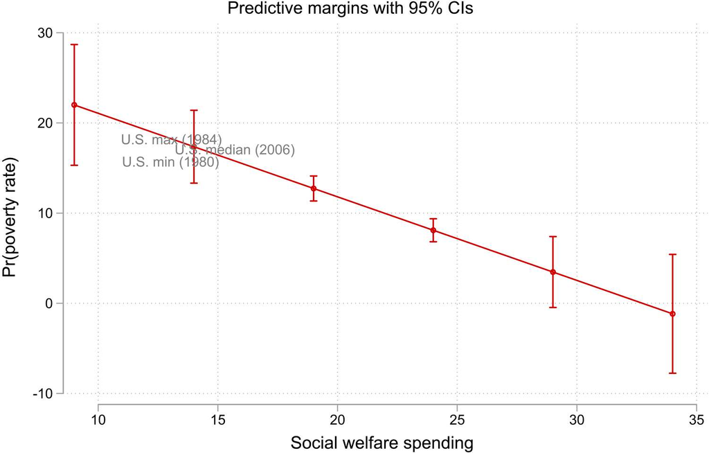

Predicted poverty rates from a two-way fixed-effects model of social welfare spending (% of GDP) in 20 rich democracies, 1980–2019, with 95% CIs, overlaid with the actual U.S. minimum (1980), median (2006) and maximum (1984) poverty rates. Brady (2023), Fig. 8.

## (b) Penalties are political choices

Behaviouralists assume a mechanical link from behavioural risk to poverty, so they try to reduce the *prevalence* of risks.

Political explanations: states decide which risks are protected. The *penalty* varies across countries and is politically manipulable.

## (c) Power resources

The default distribution of power in a capitalist democracy favours elites and business.

Unions and Left parties organise the less advantaged. Poverty is lower where Left parties govern, unionisation is higher, and women are a larger share of parliaments.

So the field should study the choices of **political actors who have power over the poor**, not yet again the choices of the poor.

## (d) Institutions

Institutions are “the residue of the power of collective actors in the past”. They stay consequential without active maintenance.

Linked to poverty: slavery, federalism, electoral systems, colonialism, criminal justice, labour market institutions, minimum wages, citizenship laws.

Two examples. **Citizenship** laws block access to social policy and employment. State-supported segregation and historical racial regimes put **racism** at the centre, which the three prevailing approaches barely mention.

# Conclusion

US poverty is high, stable, and everywhere

Explanations that start from the individual poor cannot account for it

Explanations that start from power, policy and institutions can

# 4. Perspectives for psychology

Can psychology, a discipline whose unit is **the individual**, help study poverty rather than the poor?

## What the psychology of poverty has done so far (Sheehy‐Skeffington et al. 2026)

Fifteen years of experiments showing that being poor changes how people think and decide: attention narrows to the present, long-term planning suffers

This was welcomed as a reversal of the old story: poverty causes the behaviour, not the other way round

Governments and funders responded with interventions to improve the decisions of people living in poverty

## Their problem with it, which is Brady’s problem

It still focuses on the behaviour of poor people, not why there is poverty

Helping some individuals decide better may move them up. It does not tackle the structural and political causes.

Offering individual fixes can even reduce public support for structural ones

## Their proposal: study poverty “outside-in”

Start at the widest level and work inward. At each level: what does this do to people, and what should psychology study?

**Macro- and exosystem.** The welfare regime and the ideology behind it

**Mesosystem.** The design and implementation of specific social policies

**Microsystem.** The proximal material and social conditions of poverty

## Macro- and exosystem: the welfare regime

Liberal regimes (US, UK): support must be earned and is policed, through job-search requirements, sanctions, even drug tests. Linked to stigma and worse mental health

Social-democratic regimes (Nordics): benefits are a right of residence. Less stigma, support read as solidarity rather than failure

Welfare regimes are “moral environments”: they shape how poverty feels and how poor people are judged

## What psychology should do at this level

- Compare welfare regimes to find the institutional features that reduce stigma and moral suspicion and strengthen perceived security and belonging
- Study the psychological consequences of “liberalisation”, the drift of every regime towards the US model
- Join the debate on how to organise society: on their reading, the social-democratic model is “plausibly the most psychologically protective”

## Mesosystem: three choices in policy design

**Universal or targeted?** Targeting labels people as recipients, and the label carries a stereotype: less hardworking, less competent. Having to apply and prove eligibility keeps eligible people out

**Unconditional or conditional?** Making benefits depend on job search lowers wellbeing and shifts responsibility for basic needs from the state to the individual

**Protected or precarious work?** Working poverty is growing. Precarious contracts push the risk onto the worker, strong unions raise wages and job quality for union and non-union workers alike

## What psychology should do at this level

- Evaluate policy features for their psychological effects: universal versus means-tested, unconditional versus conditional
- Study predistribution: how precarious work and collective bargaining rights shape the experience of people at risk of poverty, including the “benefits and pitfalls” of labour-market reforms
- Build causal evidence, because “research on its psychological dimension is sparse and limited in causal insight”

## Microsystem: the daily conditions of being poor

Harshness: scarce resources, unsafe surroundings, pollution and heat. Unpredictability: income, work hours, housing, childcare

In such an environment, taking the money now and avoiding risks is adaptive, not a failure of self-control

Some famous lab effects may be artefacts: in the scarcity games, “rich” participants rarely needed to borrow at all

## What psychology should do at this level

- Intervene on the environment, not the person: predictable income, safe housing and workplaces, child poverty first
- Redesign settings that penalise people adapted to adversity: test questions, class-sensitive teaching, payment schedules, simple application processes
- Rule out structural constraints before invoking a psychological shift

## So what changes for psychological research on poverty?

**The object of study.**

- From the behaviour of people in poverty to the psychological consequences of specific institutional and policy design choices
- From improving the decisions of the poor to evaluating policy designs and studying the politics that could change them

## Helping the poor or fighting poverty?

Their research agenda:

- quasi-experimental and longitudinal comparisons of how different welfare logics shape psychological processes over time
- economic games whose institutional rules mimic different political and economic configurations
- how to promote participation in labour unions and collective movements
- the psychological foundations of voting for egalitarian or universalist platforms
- the psychology of policymakers: why they fail to implement what they advocate

## References

Brady, David. 2023. “Poverty, Not the Poor.” *Science Advances* 9 (34): eadg1469. https://doi.org/10.1126/sciadv.adg1469.

Chater, Nick, and George Loewenstein. 2023. “The i-Frame and the s-Frame: How Focusing on Individual-Level Solutions Has Led Behavioral Public Policy Astray.” *Behavioral and Brain Sciences* 46: e147. https://doi.org/10.1017/S0140525X22002023.

Sheehy‐Skeffington, Jennifer, Julia Buzan, Iván Cano, Fiona Tho Pesch, and Jessica Rea. 2026. “Bringing a Wider Socioecological Lens to the Psychology of Poverty.” *Social Issues and Policy Review* 20 (1): e70010. https://doi.org/10.1111/sipr.70010.

# Backup

## Child poverty over time

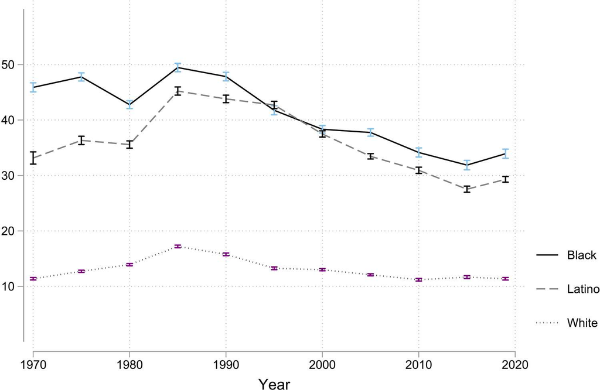

Child poverty rates for Black (solid), Latino (dashed) and white (dotted) children in the United States, 1970–2019, with 95% CIs. Brady (2023), Fig. 4.

## Institutions: citizenship

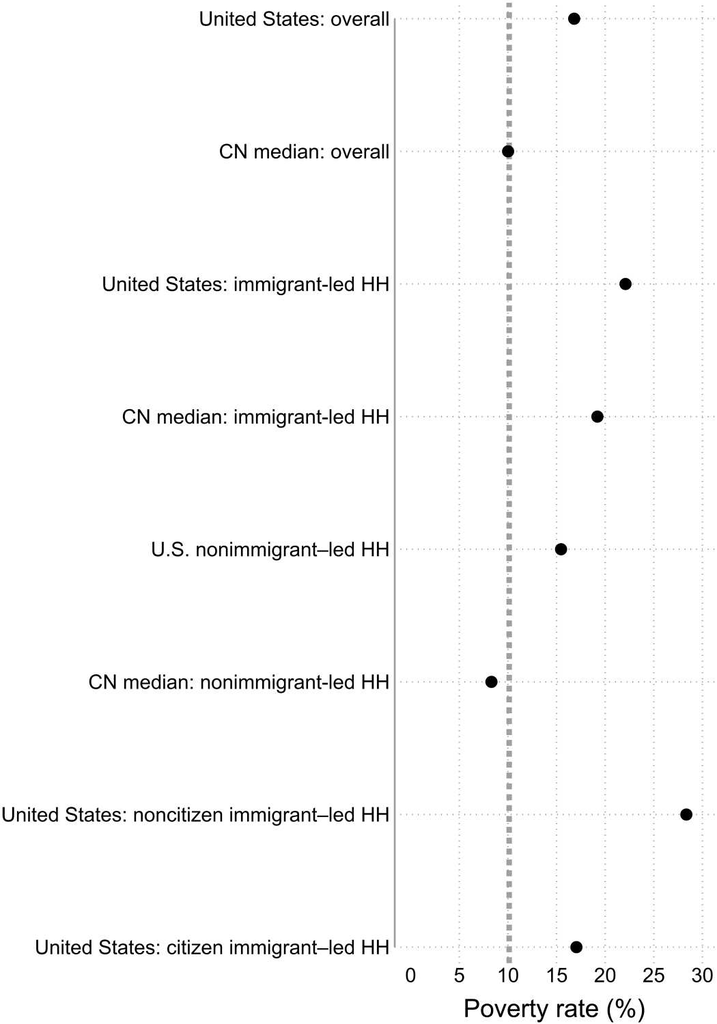

Poverty rates by immigrant and citizenship status of the household, United States (2016–2020) versus the cross-national median of 24 rich democracies. Dotted line: CN median for the overall population. Brady (2023), Fig. 9.